Ahmad Y Abuhelwa, David J.R Foster, Richard N Upton

2017-01-16

## Introduction

ADVAN-style analytical solutions for 1, 2, 3 compartment linear pharmacokinetic models of intravenous bolus, infusion, and first-order absorption have been derived and published by [Abuhelwa et al., 2015](http://www.ncbi.nlm.nih.gov/pubmed/25841670) [^1]. The analytical solutions are used to simulate the time-course of drug amounts in the compartments of a pharmacokinetic models and they “advance” the solution of the model from one time point to the next, allowing for any dose or time-varying covariate factors to be accounted for. The ADVAN-style analytical solutions were coded in the R programming language [^2] and have been shown to have speed advantages over solutions using differential equation solvers [1].

## Aims

The aims of this work were to:

- Enhance the computational speed of the ADVAN-style analytical functions through coding them in hybrid R/C++ programming languages for faster simulation processing.
- Present the ADVAN-style analytical functions in an R package, **PKADVAN package** and make them available for the wider audience.
- Expand the “PKADVAN” package library to include other pharmacokinetic models such as transit first-order absorption and metabolite models.

## Methods

- The ADVAN-style analytical solutions were derived using Laplace transforms and then were coded in the C++ programming language and integrated into R using the Rcpp package attributes [^3].
- The integrated R/C++ ADVAN-style analytical functions were built into an open-source R package (“PKADVAN” package).
- To assess computational speed, simulations for 1000 subjects using three compartment IV bolus, infusion, and first-order absorption models were performed and compared to relative computational speed of the equivalent R-coded functions. For each subject, two doses were simulated with the evaluations performed at 1 hour time intervals for 2 days.
- All pharmacokinetic models incorporated into the PKADVAN package have been validated against the commercially available population pharmacokinetic modelling software NONMEM.

## PKADVAN package

###### Table 1: Pharmacokinetic models of the ‘PKADVAN’ library

| Category | Pharmacokinetic model | PKADVAN function name |
| --- | --- | --- |
| Basic PK models | 1 comp IV bolus | `OneCompIVbolus` |
| Basic PK models | 2 comp IV bolus | `TwoCompIVbolus` |
| Basic PK models | 3 comp IV bolus | `ThreeCompIVbolus` |
| Basic PK models | 1 comp IV infusion | `OneCompIVinfusion` |
| Basic PK models | 2 comp IV infusion | `TwoCompIVinfusion` |
| Basic PK models | 3 comp IV infusion | `ThreeCompIVinfusion` |
| Basic PK models | 1 comp first-order absorption | `OneCompFirstOrderAbs` |
| Basic PK models | 2 comp first-order absorption | `TwoCompFirstOrderAbs` |
| Basic PK models | 3 comp first-order absorption | `ThreeCompFirstOrderAbs` |
| Transit first-order absorption models | 1 comp-1 transit | `OneCompOneTransit` |
| Transit first-order absorption models | 1 comp-2 transit | `OneCompTwoTransit` |
| Transit first-order absorption models | 1 comp-3 transit | `OneCompThreeTransit` |
| Transit first-order absorption models | 1 comp-4 transit | `OneCompFourTransit` |
| Transit first-order absorption models | 2 comp-1 transit | `TwoCompOneTransit` |
| Transit first-order absorption models | 2 comp-2 transit | `TwoCompTwoTransit` |
| Transit first-order absorption models | 2 comp-3 transit | `TwoCompThreeTransit` |
| Transit first-order absorption models | 2 comp-4 transit | `TwoCompFourTransit` |
| First-order formation metabolite models | 1 comp IV bolus-1 comp metabolite | `OneCompIVbolusOneCompMetab` |
| First-order formation metabolite models | 2 comp IV bolus-1 comp metabolite | `TwoCompIVbolusOneCompMetab` |
| First-order formation metabolite models | 3 comp IV bolus-1 comp metabolite | `ThreeCompIVbolusOneCompMetab` |
| First-order formation metabolite models | 1 comp IV infusion-1 comp metabolite | `OneCompIVinfusionOneCompMetab` |
| First-order formation metabolite models | 2 comp IV infusion-1 comp metabolite | `TwoCompIVinfusionOneCompMetab` |
| First-order formation metabolite models | 3 comp IV infusion-1 comp metabolite | `ThreeCompIVinfusionOneCompMetab` |
| First-order formation metabolite models | 1 comp first-order absorption-1 comp metabolite | `OneCompFirstOrderAbsOneCompMetab` |
| First-order formation metabolite models | 2 comp first-order absorption-1 comp metabolite | `TwoCompFirstOrderAbsOneCompMetab` |
| First-order formation metabolite models | 3 comp first-order absorption-1 comp metabolite | `ThreeCompFirstOrderAbsOneCompMetab` |

###### Table2: Comparison of computation time: R-functions versus the integrated R/C++ PKADVAN functions

| Pharmacokinetic model | R-functions (seconds)<sup>a</sup> | PKADVAN functions (seconds)<sup>a</sup> | Relative speed |
| --- | --- | --- | --- |
| 3 comp IV bolus | 20.37 ± 0.08 | 1.33 ± 0.02 | 15.32 |
| 3 comp first-order absorption | 26.70 ± 0.42 | 1.52 ± 0.01 | 17.57 |
| 3 comp IV-infusion | 61.42 ± 0.17 | 5.04 ± 0.05 | 12.19 |
| 3 comp first-order absorption-extended<sup>b</sup> | 64.67 ± 0.17 | 1.90 ± 0.02 | 33.98 |

<sup>a</sup> Mean ± SD computation time required to process simulations for 1000 subjects based on three compartment intravenous bolus, infusion, and first-order absorption models. For each subject, two doses were simulated with the evaluations performed at 1 hour time intervals for 2 days.

<sup>b</sup> The same dosing regimen simulations extended for 5 days.

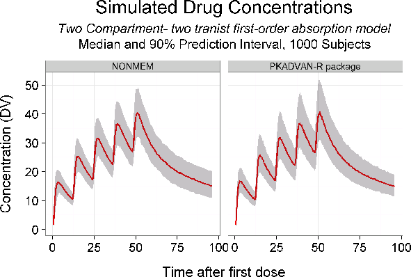

## Simulation Example

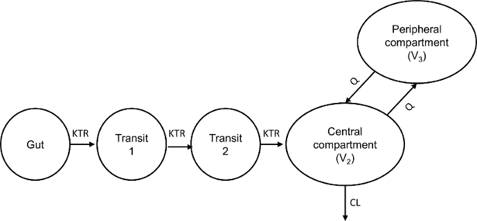

### Step 1: Generate a NONMEM-style data frame

If you have a NONMEM-style data frame then load it into R and skip this step, otherwise, use R to generate a simulation data frame.

```r
rm(list=ls(all=TRUE))
    graphics.off()

#load packages
    library(PKADVAN)
    library(plyr)
    library(ggplot2)

#Function for 90% confidence intervals calculation
    CI90lo <- function(x) quantile(x, probs=0.05,na.rm=T)
    CI90hi <- function(x) quantile(x, probs=0.95,na.rm=T)

#-----------------------------------------------
# Generate a NONMEM-style simulation data frame
#-----------------------------------------------
    #Set dose records: It can be arbitrary.
    dosetimes <- c(seq(0,48,12))
    tlast <- 96

    #Now define finer sample times for after a dose to capture Cmax
    doseseq <- c(0,0.5,1,1.5,2,2.5,3,3.5,4,4.5,5,5.5,6,7,8,9,10)

    #Use the outer product but with addition to expand this doseseq for all dosetimes
    PKtimes <- outer(dosetimes,doseseq,"+")

    #set number of subjects
    nsub <- 1000
    ID <- 1:nsub

    #Make dataframe
    df <- expand.grid("ID"=ID,"TIME"=sort(unique(c(seq(0,tlast,1),PKtimes))),"AMT"=0,"MDV"=0,"DV"=NA,"CLCR"=120)

    df$CLCR[df$TIME >= 36] <- 80  #Allow CLCR to change

    doserows <- subset(df, TIME%in%dosetimes)

    #Dose: It can be any arbitrary dose
    doserows$AMT <- 500
    doserows$MDV <- 1

    #Add back dose information
    df <- rbind(df,doserows)
    df <- subset(df, (TIME==0 & AMT==0)==F) # remove the row that has a TIME=0 and AMT=0
    head(df)
```

```
##      ID TIME AMT MDV DV CLCR
## 1001  1  0.5   0   0 NA  120
## 1002  2  0.5   0   0 NA  120
## 1003  3  0.5   0   0 NA  120
## 1004  4  0.5   0   0 NA  120
## 1005  5  0.5   0   0 NA  120
## 1006  6  0.5   0   0 NA  120
```

### Step 2: Define parameters of the pharmacokinetic model

This includes setting population PK parameters, between subject variability, and residual error model parameters.

```r
#----------------------------------------------------------------------------
# Two compartment-2 transit first-order absorption model via PKADVAN package
#----------------------------------------------------------------------------
#Define between subject variability on PK parameters
    #BSV (Omegas as SD)
    ETA1CL  <- 0.15
    ETA2V2  <- 0.12
    ETA3Q   <- 0.14
    ETA4V3  <- 0.05
    ETA5KTR <- 0.30

#Define residual error model
    #Residuals (Epsilons as SD)
    EPS1    <- 0.10     #Proportional residual error
    EPS2    <- 0.15     #Additive residual error

    #Use random number generator to simulate residuals from a normal distribution
    BSVCL   <- rnorm(nsub, mean = 0, sd = ETA1CL)   #BSV on CL
    BSVV2   <- rnorm(nsub, mean = 0, sd = ETA2V2)   #BSV on V2
    BSVQ    <- rnorm(nsub, mean = 0, sd = ETA3Q)    #BSV on Q
    BSVV3   <- rnorm(nsub, mean = 0, sd = ETA4V3)   #BSV on V3
    BSVKTR  <- rnorm(nsub, mean = 0, sd = ETA5KTR)  #BSV on KTR

    EPS1 <- rnorm(nsub, mean = 0, sd = EPS1)    #Proportional residual error
    EPS2 <- rnorm(nsub, mean = 0, sd = EPS2)    #Additive residual error

#Set population PK parameters for 2-compartment First-order absorption model
    CLpop   <- 0.5      #central clearance
    V2pop   <- 20       #central volume of distribution
    Qpop    <- 1        #inter-compartmental clearance
    V3pop   <- 25       #peripheral volume of distribution
    KTRpop  <- 2.05     #first-order absorption rate constant
    F1pop   <- 0.80     #Bioavailability
```

### Step 3: Modify the simulation data frame for PKADVAN calculation and include any covariates on the PK parameters

```r
inputDataFrame <- df
#Calculate group parameter values including any covariate effects
    inputDataFrame$CL  <- CLpop*exp(BSVCL)*(inputDataFrame$CLCR/100)   #creatinine clearance added as a time-changing covariate on CL
    inputDataFrame$V2  <- V2pop*exp(BSVV2)
    inputDataFrame$Q   <- Qpop*exp(BSVQ)
    inputDataFrame$V3  <- V3pop*exp(BSVV3)
    inputDataFrame$KTR <- KTRpop*exp(BSVKTR)
    inputDataFrame$F1  <- F1pop
#This is crucial!
    inputDataFrame <- inputDataFrame[order(inputDataFrame$ID,inputDataFrame$TIME,inputDataFrame$AMT),] # Arrange df by TIME (ascending) and by AMT (descending)
    head(inputDataFrame)
```

```
##        ID TIME AMT MDV DV CLCR        CL       V2         Q       V3
## 127001  1  0.0 500   1 NA  120 0.5659385 23.20982 0.9312761 25.54465
## 1001    1  0.5   0   0 NA  120 0.5659385 23.20982 0.9312761 25.54465
## 2001    1  1.0   0   0 NA  120 0.5659385 23.20982 0.9312761 25.54465
## 3001    1  1.5   0   0 NA  120 0.5659385 23.20982 0.9312761 25.54465
## 4001    1  2.0   0   0 NA  120 0.5659385 23.20982 0.9312761 25.54465
## 5001    1  2.5   0   0 NA  120 0.5659385 23.20982 0.9312761 25.54465
##             KTR  F1
## 127001 2.831367 0.8
## 1001   2.831367 0.8
## 2001   2.831367 0.8
## 3001   2.831367 0.8
## 4001   2.831367 0.8
## 5001   2.831367 0.8
```

### Step 4: Apply PKADVAN function of the selected PK model

To simulate a population (i.e. the `inputDataFrame` has more than one subject `ID`), the function has to be applied for each subject `ID`. One way of doing that is through using the `ddply` functionality in the **plyr** package in R. The `ddply` functionality allows applying the PKADVAN function to each subject ID and combines the results into a data frame.

The function calculates the amounts in the absorption (`A1`), first, and second transit (`A4, A5`), respectively, central (`A2` & individual predicted concentrations, `IPRED`) and peripheral compartment (`A3`) and returns the output added to the inputDataFrame

```r
simdf <- ddply(inputDataFrame, .(ID), TwoCompTwoTransit)
head(simdf)
```

```
##   ID TIME AMT MDV DV CLCR        CL       V2         Q       V3      KTR
## 1  1  0.0 500   1 NA  120 0.5659385 23.20982 0.9312761 25.54465 2.831367
## 2  1  0.5   0   0 NA  120 0.5659385 23.20982 0.9312761 25.54465 2.831367
## 3  1  1.0   0   0 NA  120 0.5659385 23.20982 0.9312761 25.54465 2.831367
## 4  1  1.5   0   0 NA  120 0.5659385 23.20982 0.9312761 25.54465 2.831367
## 5  1  2.0   0   0 NA  120 0.5659385 23.20982 0.9312761 25.54465 2.831367
## 6  1  2.5   0   0 NA  120 0.5659385 23.20982 0.9312761 25.54465 2.831367
##    F1          A1         A4        A5        A2         A3     IPRED
## 1 0.8 400.0000000   0.000000  0.000000   0.00000  0.0000000  0.000000
## 2 0.8  97.1038685 137.468328 97.305810  67.44916  0.4178443  2.906061
## 3 0.8  23.5729032  66.743532 94.487706 210.04427  3.1928593  9.049800
## 4 0.8   5.7225502  24.303957 51.610060 304.83692  8.3633339 13.133961
## 5 0.8   1.3892044   7.866694 22.273495 344.56618 14.7392455 14.845705
## 6 0.8   0.3372428   2.387145  8.448604 353.93507 21.4489048 15.249365
```

```r
#plot IPRED
    plotobj <- NULL
    titletext <- expression(atop("Simulated Drug Concentrations",
                                 atop(italic("Two compartment- two tranist first-order absorption"),"Median and 90% Prediction Interval, 1000 subjects")))
    plotobj <- ggplot(data=simdf)
    plotobj <- plotobj + stat_summary(aes(x=TIME, y= IPRED),fun.y=median, geom="line", colour="red", size=1)
    plotobj <- plotobj + stat_summary(aes(x=TIME, y= IPRED),geom="ribbon", fun.ymin="CI90lo", fun.ymax="CI90hi", alpha=0.3)
    plotobj <- plotobj + ggtitle(titletext)
    plotobj <- plotobj + scale_y_continuous("IPREDs\n")
    plotobj <- plotobj + scale_x_continuous("\nTime after dose")
```

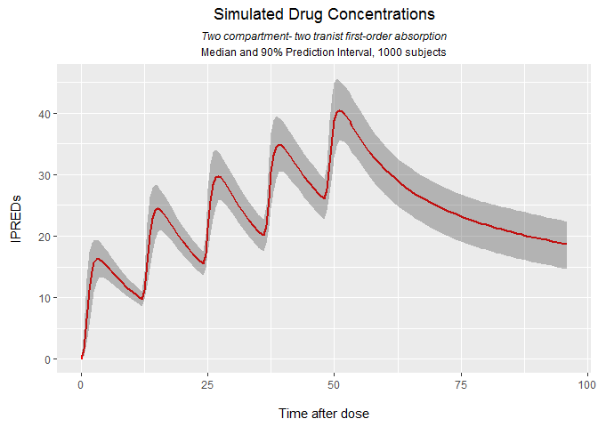

```r
  plotobj
```

### Step 5: Add residual unexplained variability (within subject variability) on IPREDs

```r
#combined additive and proportional error model
    simdf$DV <- simdf$IPRED*(1 + EPS1) + EPS2

#Plotting
    #Subset missing data
    simdf <- subset(simdf, MDV==0)
 #DV
    plotobj <- NULL
    titletext <- expression(atop("Simulated Drug Concentrations",
                                 atop(italic("Two compartment- two tranist first-order absorption"),"Median and 90% Prediction Interval, 1000 subjects")))

    plotobj <- ggplot(data=simdf)
    plotobj <- plotobj + stat_summary(aes(x=TIME, y= DV),fun.y=median, geom="line", colour="red", size=1)
    plotobj <- plotobj + stat_summary(aes(x=TIME, y= DV),geom="ribbon", fun.ymin="CI90lo", fun.ymax="CI90hi", alpha=0.3)
    plotobj <- plotobj + ggtitle(titletext)
    plotobj <- plotobj + scale_y_continuous("DV\n")
    plotobj <- plotobj + scale_x_continuous("\nTime after dose")
```

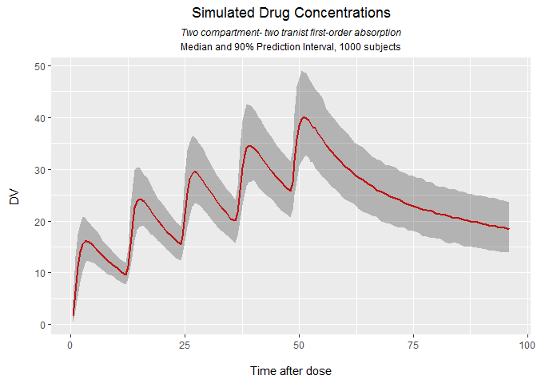

```r
  plotobj
```

## Applications

- The PKADVAN package can be used for performing simulations from stochastic population pharmacokinetic models coded in R and incorporated into reactive ‘Shiny’ web applications where speed is important as it allows for simulating larger populations without compromising the reactivity of the Shiny application.
- The PKADVAN package can be implemented for data fitting, and for calculating confidence and prediction intervals of pharmacokinetic models’ parameters [^4].
- The PKADVAN package could be incorporated into an open-source mixed-effect modelling framework to estimate population parameters where speed is always desirable.

## Conclusions

With its speed advantages and the capacity to handle arbitrary dosing regimens and covariate structures, the “PKADVAN” package is expected to facilitate the investigation of a useful open-source software for modelling and simulating pharmacokinetic data.

## To do list

- Implement steady-state functionality, as achieved with the SS and II data items in NONMEM.
- Implement analytical solutions for combined dosing regimens (e.g., IV bolus plus infusion).
- Implement the analytical solutions for fitting population PK data
[^1]: Abuhelwa AY, Foster DJ, Upton RN. 2015. ADVAN-style analytical solutions for common pharmacokinetic models. J Pharmacol Toxicol Methods 73:42-48.
[^2]: R Core Team. 2014. R: A Language and Environment for Statistical Computing R Foundation for Statistical Computing, Vienna, Austria.
[^3]: Eddelbuettel D, François R, Allaire J, Chambers J, Bates D, Ushey K. 2011. Rcpp: Seamless R and C++ integration. Journal of Statistical Software 40:1-18.
[^4]: Kümmel A, Abuhelwa AY, Dingemanse J, Krause A. PECAN, a Shiny application for calculating confidence and prediction intervals for pharmacokinetic and pharmacodynamic models. The twenty-fifth Annual Population Approach Group Europe (PAGE) Meeting. 2016